# Reproducing analyses from the NICE Evidence Synthesis Technical Support Documents in MetaInsight v1.0

# 4 TSD3 Example 5, Certolizumab: baseline risk

## 4.1 Create the dataset

Follow the steps in section 3.1.

## 4.2 Analyse the data

Follow the steps in section 3.2 up to the stage of selecting the **Meta-regression** tab. Within the **Meta-regression** tab, select the **Baseline Risk Analysis** tab. Leave the type of regression coefficient at the default *shared* and click the **Click here to run the main analysis for all studies** button.

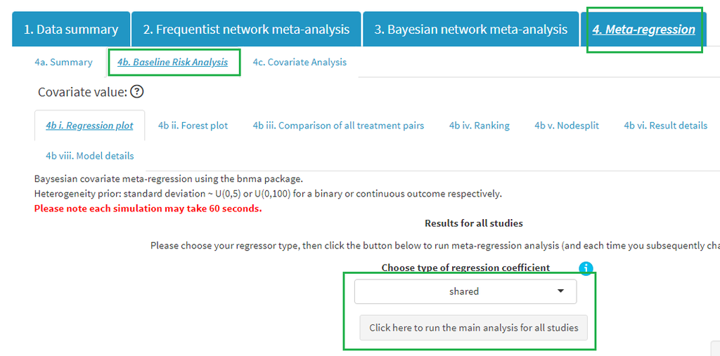

## 4.3 Compare the results

The results from WinBUGS are shown in Table 8 on page 45 of the TSD3 pdf file:

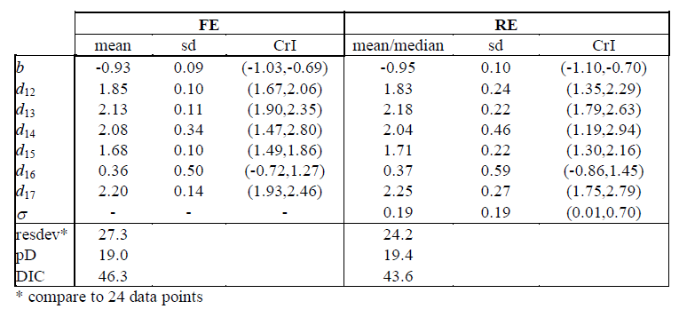

The relative treatment effects $d_{12}$, …, $d_{17}$ and their 95% credible intervals (on the odds ratio scale) are displayed in the forest plot in MetaInsight. The one below is from the random effects model.

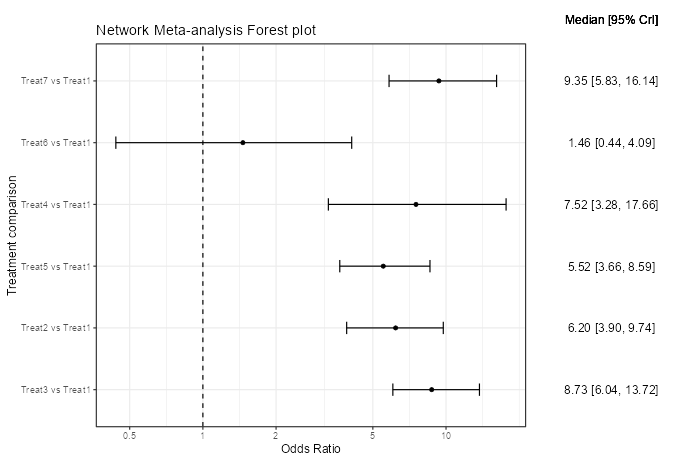

The medians and standard deviations of the relative treatment effects are available in the **Bayesian result details** tab, which also displays statistics on the shared covariate parameter $b$. Note that in contrast to the covariate meta-regression there is no scaling in MetaInsight in the baseline risk model, so this parameter is the same as the MetaInsight parameter $b\_bl$.

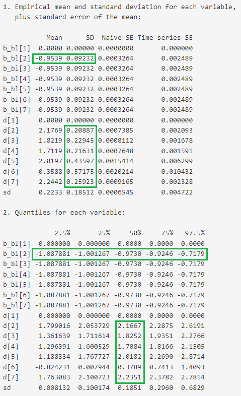

$resdev$ ($Dbar$ in MetaInsight), $p_D$, and $DIC$ are all provided underneath the forest plot. The mean of $\sigma$ and its 95% credible interval can also be found there for the random effects model. The median and standard deviation of $\sigma$ can be found in the **Bayesian result details** tab in the **sd** rows (above).

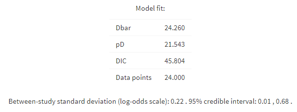

A plot showing the regression lines is on page 39 of TSD3:

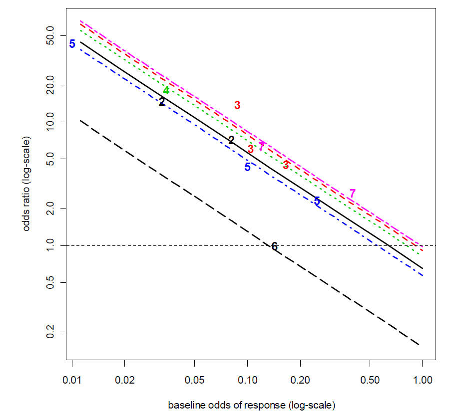

This is the equivalent plot in MetaInsight, which also displays study contributions and confidence regions:

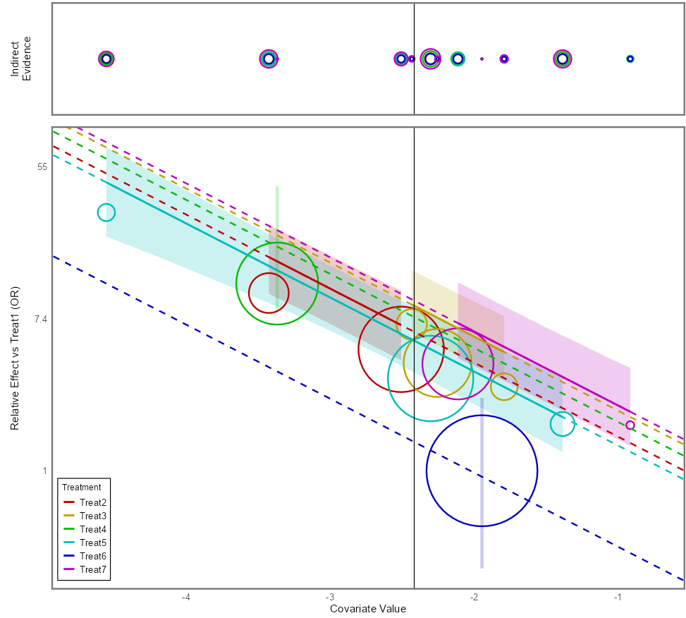